# Data Visualization Part 1

K. D. Erickson

July 1, 2022

This document arose from a presentation made for GCCL Lab Group on July 1, 2022

# Data Visualization Part 1

## 2022-07-01

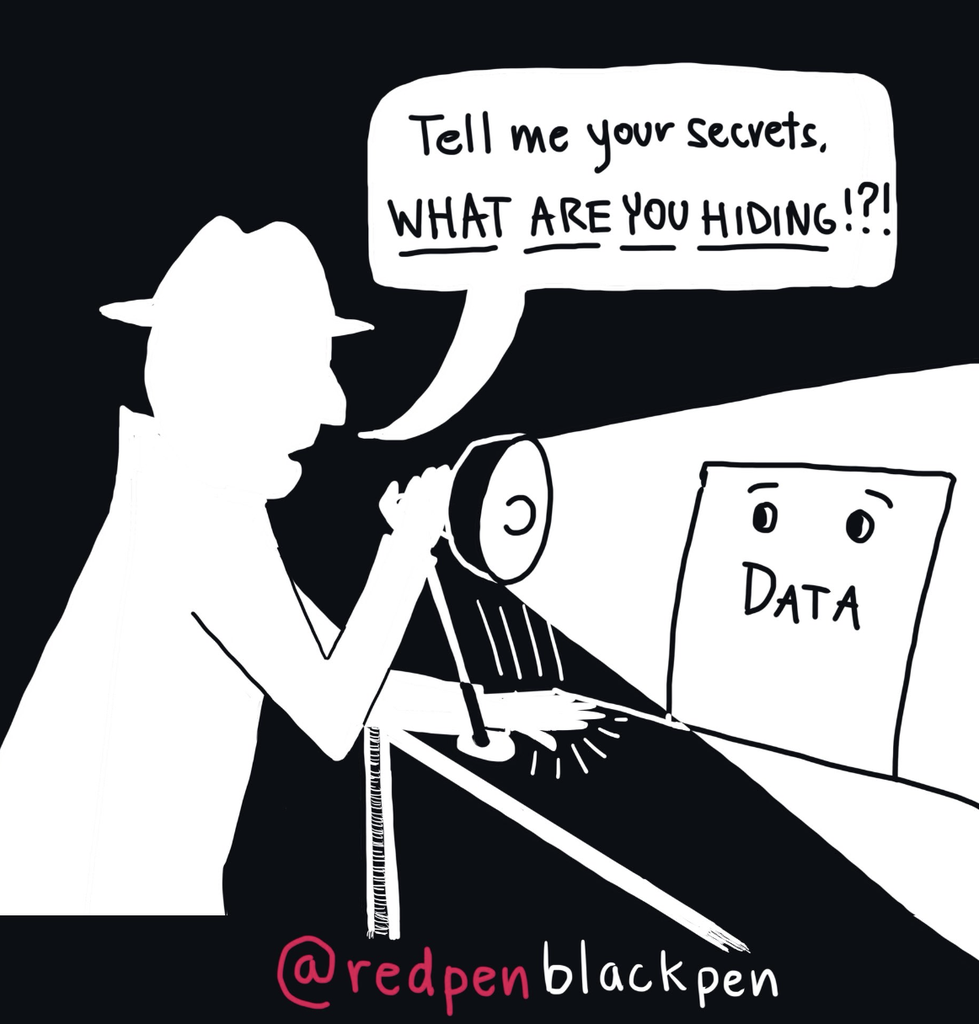

# Deciding what to plot

- Do **species** have different **petal lengths**?

```r
kable(summary(iris))
```

|  | Sepal.Length | Sepal.Width | Petal.Length | Petal.Width | Species |
| --- | --- | --- | --- | --- | --- |
|  | Min. :4.300 | Min. :2.000 | Min. :1.000 | Min. :0.100 | setosa :50 |
|  | 1st Qu.:5.100 | 1st Qu.:2.800 | 1st Qu.:1.600 | 1st Qu.:0.300 | versicolor:50 |
|  | Median :5.800 | Median :3.000 | Median :4.350 | Median :1.300 | virginica :50 |
|  | Mean :5.843 | Mean :3.057 | Mean :3.758 | Mean :1.199 | NA |
|  | 3rd Qu.:6.400 | 3rd Qu.:3.300 | 3rd Qu.:5.100 | 3rd Qu.:1.800 | NA |
|  | Max. :7.900 | Max. :4.400 | Max. :6.900 | Max. :2.500 | NA |

- **Species**: Categorical variable
- **Petal Length**: Continuous variable

-[Directory of visualizations](https://clauswilke.com/dataviz/directory-of-visualizations.html)

# Hypotheses

It can be helpful to think about your research question and hypotheses before data analysis

- “I hypothesize that species with [insert life history characteristic] will have longer petals than species that do not”
- If so, I would expect:

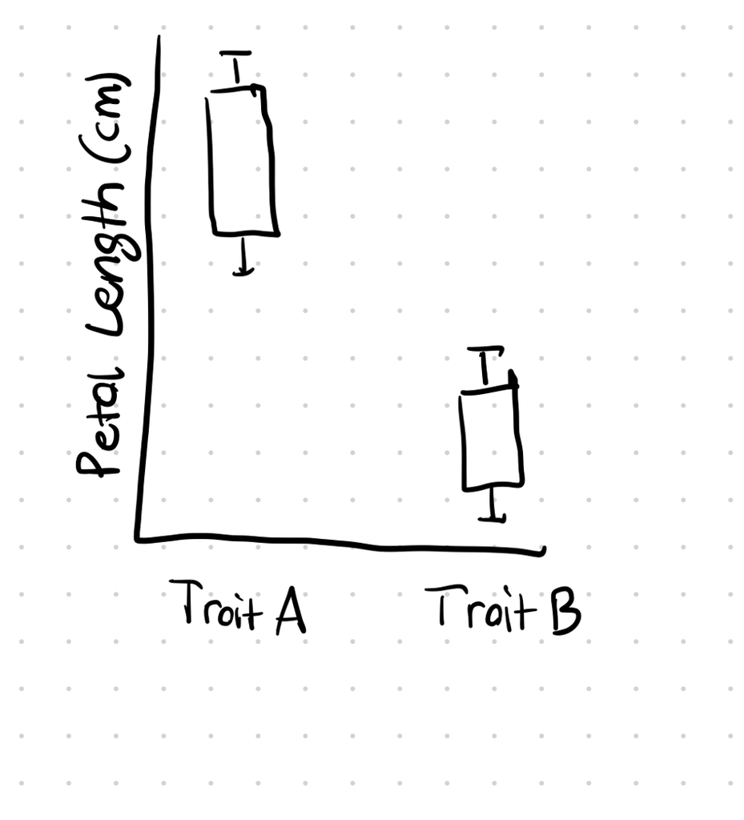

- If not, I would expect to see:

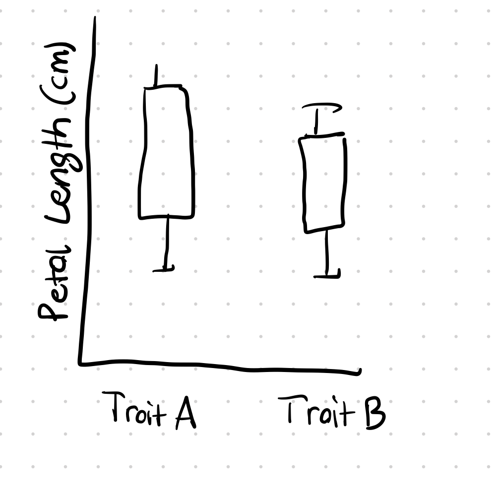

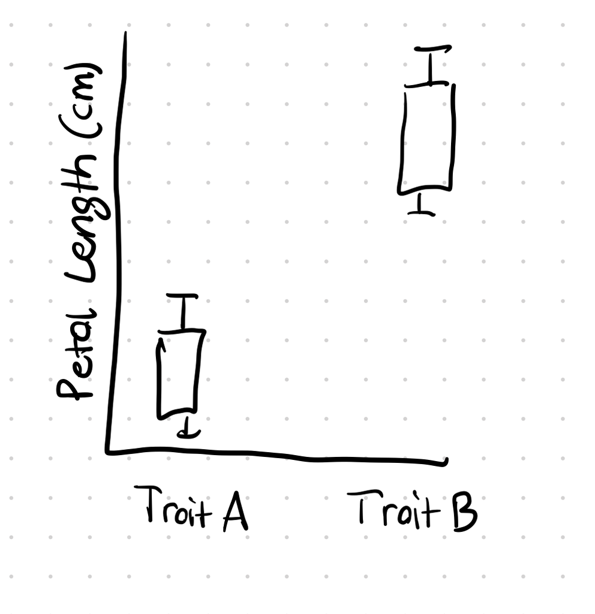

# Boxplot

[Graph Gallery: Boxplots in `ggplot2`](https://r-graph-gallery.com/boxplot.html)

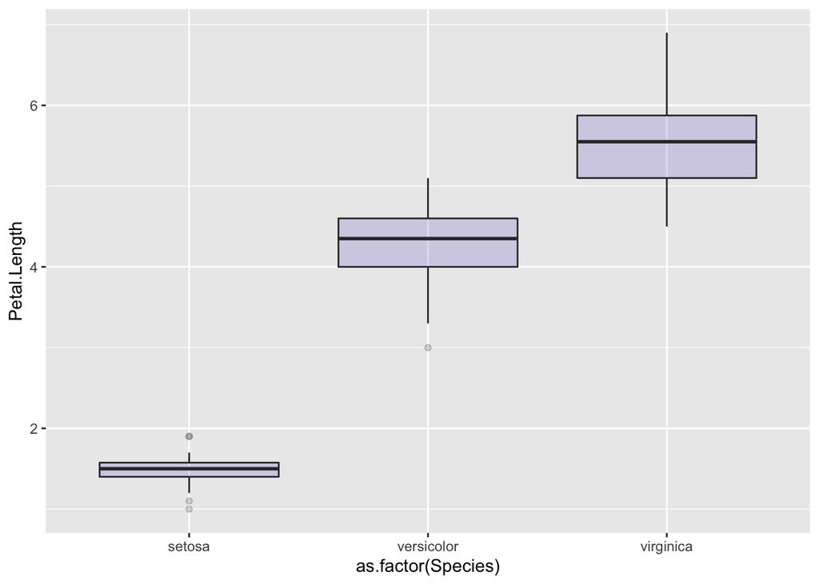

```r
library(ggplot2)
g1 <- ggplot(iris, aes(x=as.factor(Species), y=Petal.Length)) +
  geom_boxplot(fill="slateblue", alpha=0.2)

g1
```

# Incorporate Color

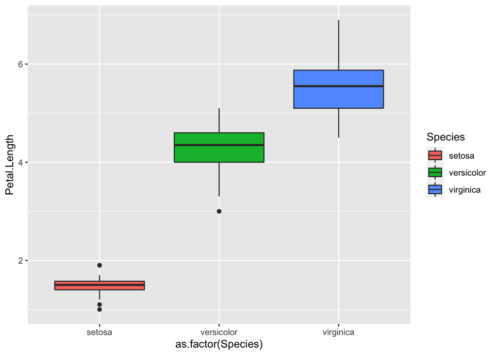

```r
g1 <- ggplot(iris, aes(x=as.factor(Species), y=Petal.Length)) +
    geom_boxplot(fill="slateblue", alpha=0.2)

g2 <- ggplot(iris, aes(x=as.factor(Species),
y=Petal.Length,
fill=Species)) +
    geom_boxplot()

g2
```

# Change color palette

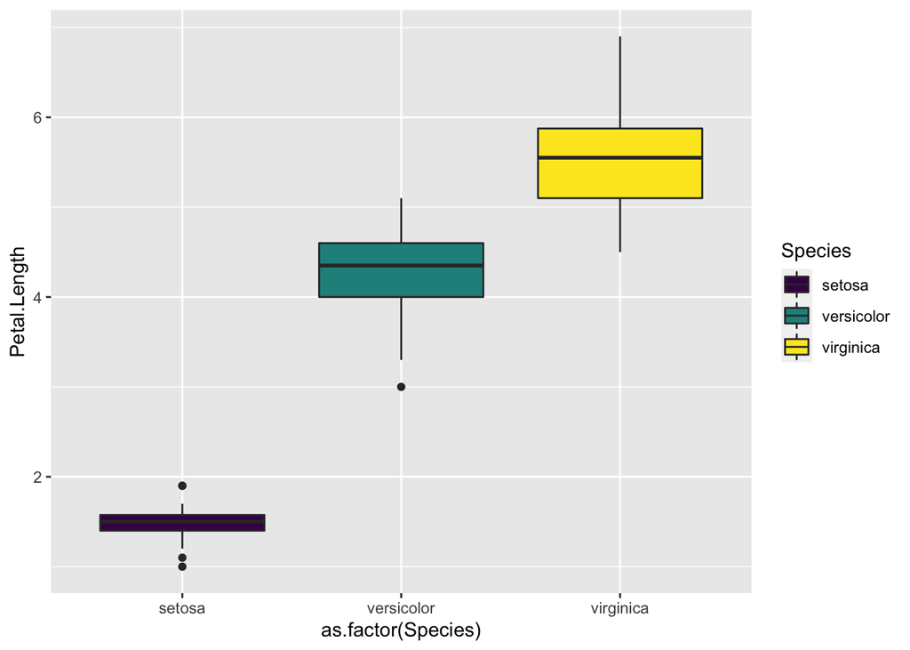

```r
library(viridis)
g2 <- g2 +
  scale_fill_viridis(discrete=T)

g2
```

# Relabel Axes

Choose human-friendly axis labels

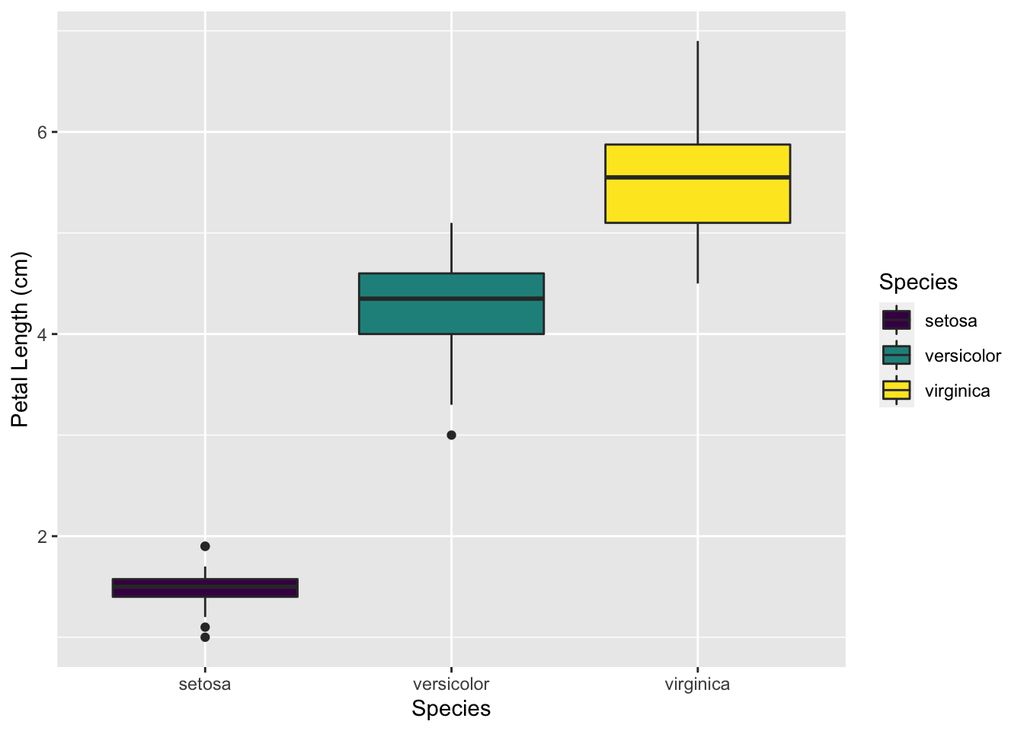

```r
g2 <- g2 +
  xlab("Species") +
  ylab("Petal Length (cm)")

g2
```

# Using color-brewer to choose colors

[ColorBrewer](https://colorbrewer2.org/)

```r
palette  <- c("#1b9e77",
              "#d95f02",
              "#7570b3")

mycolors <- c("I. setosa" = palette[1],
"I. versicolor" = palette[2],
"I. virginica" = palette[3])
```

# Rename species

```r
library(dplyr)
iris$Species <- recode(iris$Species, setosa = "I. setosa",
versicolor = "I. versicolor",
virginica = "I. virginica")
```

# Incorporate colors

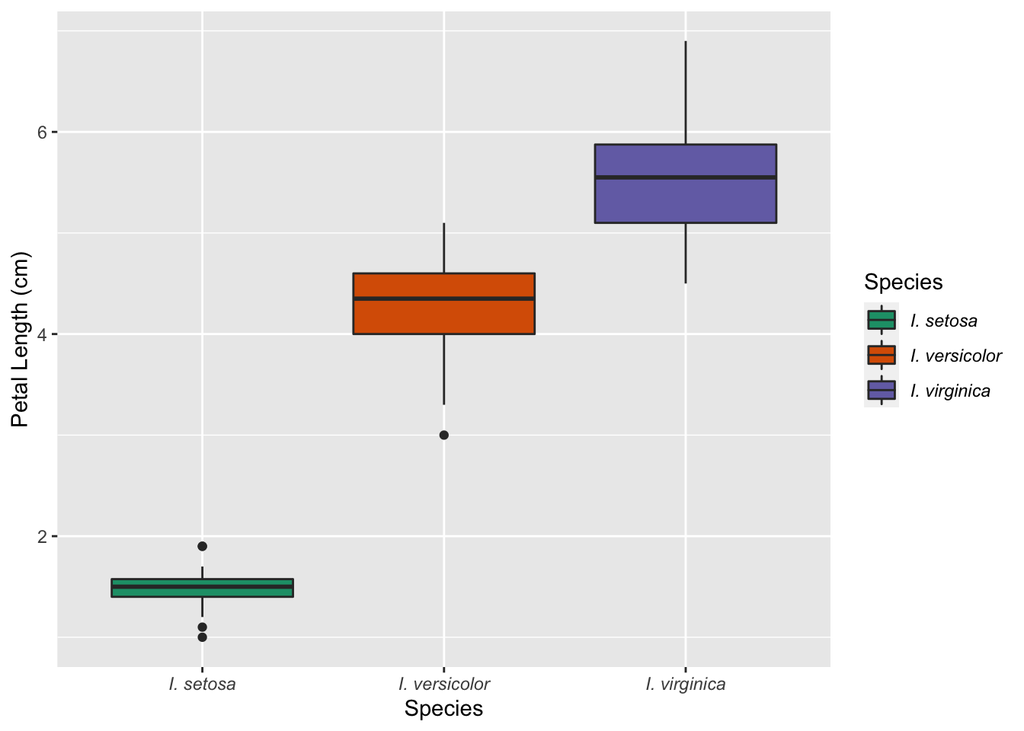

```r
g3 <- ggplot(iris, aes(x=as.factor(Species),
y=Petal.Length,fill=Species)) + geom_boxplot() + scale_fill_manual(
  values=c("I. setosa" = palette[1],
"I. versicolor" = palette[2],
"I. virginica" = palette[3]))+
  theme(axis.text.x = element_text(face = "italic"),
        legend.text = element_text(face="italic")) +
  xlab("Species") + ylab("Petal Length (cm)")

g3
```

# Increase font size!

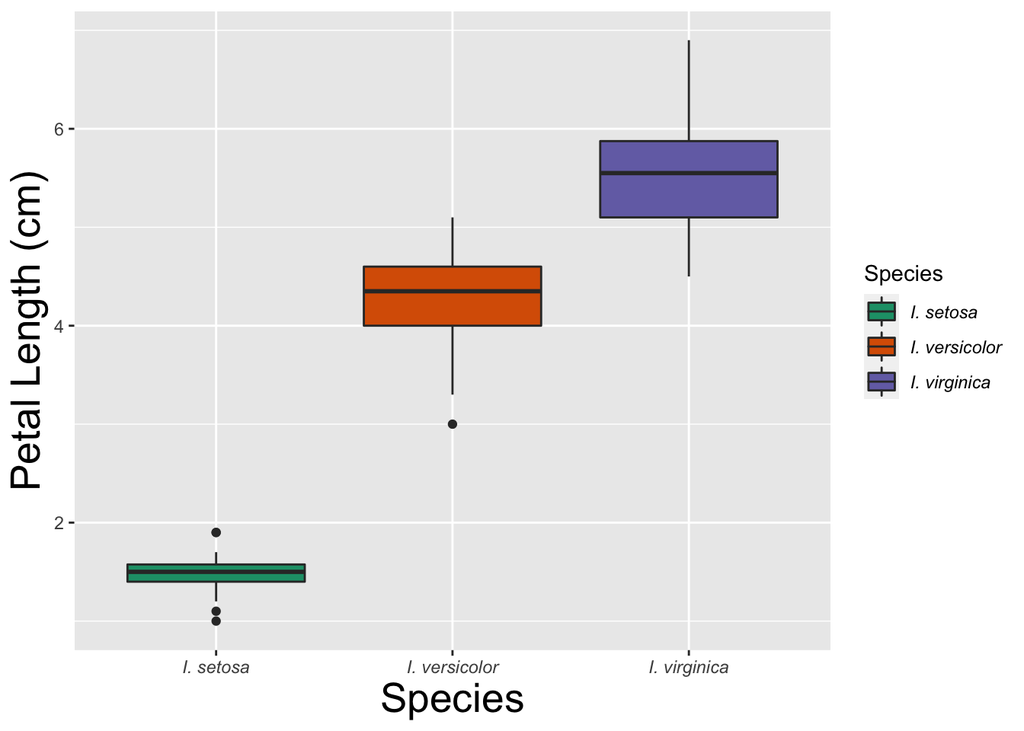

```r
g3 <- g3 + theme(axis.title = element_text(size = 20))

g3
```

# Saving your figures-1

## Straight from RStudio

You can export your figure straight from RStudio:

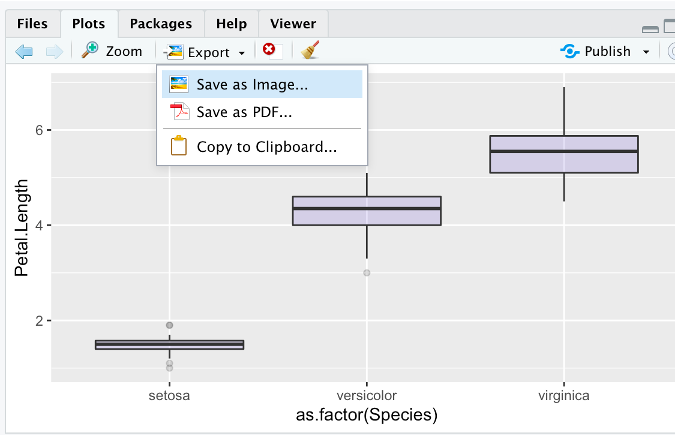

## Save as pdf

- This saves your figure as a pdf within your working directory.
- Warning: Some Mac/PC compatability issues

```r
pdf("my_figure.pdf", width=6.5,
    height=6.5, pointsize=8,
    encoding="TeXtext.enc", onefile=F)
g1
dev.off()
```

## Save as png

- This saves your figure as a .png file in your working directory.

```r
png("my_figure.png", width=6.5,
    height=8, pointsize=8,
units="in", res=300)
g3
dev.off()
```

# Some figure tips

- I recommend keeping all code to run figures in a separate script.
- After running analyses, save dataframe as a csv which can be loaded at top of figure script
- Don’t be ashamed to Google how to do things

-[Best practices for visualization concepts and presentation strategies- J. R. Carey](https://video.ucdavis.edu/media/Visualization+concepts+and+presentation+strategies+by+J.+R.+Carey/0_1hpqpmdr): An hour-long presentation on putting together talks